# Lab 5 - k-Nearest Neighbors and Discriminant Analysis

- *k*-Nearest Neighbors
  - Data Preparation
    - Dummy Variables
    - Standardization
    - Partitioning
  - *k*-NN for Classification
    - Using *k*=1
    - Determine Best *k*
  - *k*-NN for Prediction
- Discriminant Analysis
  - Data Preparation
  - Classification Functions
  - Propensities
  - Evaluating Classification Performance
  - Unequal Misclassification Costs
- Summary

# *k*-Nearest Neighbors

We will revisit the Boston Housing data to explore *k*-Nearest Neighbors for both classification and numerical prediction purposes.

## Data Preparation

```r
housing.df <- read.csv("BostonHousing.csv")
dim(housing.df)
```

```
## [1] 506  14
```

Recall the variable names and structure.

```r
t(t(names(housing.df)))
```

```
##       [,1]
##  [1,] "CRIM"
##  [2,] "ZN"
##  [3,] "INDUS"
##  [4,] "CHAS"
##  [5,] "NOX"
##  [6,] "RM"
##  [7,] "AGE"
##  [8,] "DIS"
##  [9,] "RAD"
## [10,] "TAX"
## [11,] "PTRATIO"
## [12,] "LSTAT"
## [13,] "MEDV"
## [14,] "CAT..MEDV"
```

```r
str(housing.df)
```

```
## 'data.frame':    506 obs. of  14 variables:
##  $ CRIM     : num  0.00632 0.02731 0.02729 0.03237 0.06905 ...
##  $ ZN       : num  18 0 0 0 0 0 12.5 12.5 12.5 12.5 ...
##  $ INDUS    : num  2.31 7.07 7.07 2.18 2.18 2.18 7.87 7.87 7.87 7.87 ...
##  $ CHAS     : int  0 0 0 0 0 0 0 0 0 0 ...
##  $ NOX      : num  0.538 0.469 0.469 0.458 0.458 0.458 0.524 0.524 0.524 0.524 ...
##  $ RM       : num  6.58 6.42 7.18 7 7.15 ...
##  $ AGE      : num  65.2 78.9 61.1 45.8 54.2 58.7 66.6 96.1 100 85.9 ...
##  $ DIS      : num  4.09 4.97 4.97 6.06 6.06 ...
##  $ RAD      : int  1 2 2 3 3 3 5 5 5 5 ...
##  $ TAX      : int  296 242 242 222 222 222 311 311 311 311 ...
##  $ PTRATIO  : num  15.3 17.8 17.8 18.7 18.7 18.7 15.2 15.2 15.2 15.2 ...
##  $ LSTAT    : num  4.98 9.14 4.03 2.94 5.33 ...
##  $ MEDV     : num  24 21.6 34.7 33.4 36.2 28.7 22.9 27.1 16.5 18.9 ...
##  $ CAT..MEDV: int  0 0 1 1 1 0 0 0 0 0 ...
```

There are two outcome variables here. *MEDV* is a numerical outcome representing the median home value in a census tract, while *CAT..MEDV* is a binary categorical outcome where 1 indicates the median home value is greater than $30,000.

CHAS is a binary predictor that is 1 if the census tract borders the Charles River and 0 otherwise.

We will use *RAD* as a categorical predictor here.

We will skip further EDA here, as we have performed EDA on this data previously.

### Dummy Variables

We now convert *RAD* to a factor and create dummy variables. Recall that we require a dummy variable for *every* factor level when performing *k*-NN (unlike for regression, which requires n-1).

```r
housing.df$RAD <- as.factor(housing.df$RAD) # convert to factor
dummies <- as.data.frame(model.matrix(~ 0 + RAD, data = housing.df))
housing.df <- cbind(housing.df[, -9], dummies)
str(housing.df)
```

```
## 'data.frame':    506 obs. of  22 variables:
##  $ CRIM     : num  0.00632 0.02731 0.02729 0.03237 0.06905 ...
##  $ ZN       : num  18 0 0 0 0 0 12.5 12.5 12.5 12.5 ...
##  $ INDUS    : num  2.31 7.07 7.07 2.18 2.18 2.18 7.87 7.87 7.87 7.87 ...
##  $ CHAS     : int  0 0 0 0 0 0 0 0 0 0 ...
##  $ NOX      : num  0.538 0.469 0.469 0.458 0.458 0.458 0.524 0.524 0.524 0.524 ...
##  $ RM       : num  6.58 6.42 7.18 7 7.15 ...
##  $ AGE      : num  65.2 78.9 61.1 45.8 54.2 58.7 66.6 96.1 100 85.9 ...
##  $ DIS      : num  4.09 4.97 4.97 6.06 6.06 ...
##  $ TAX      : int  296 242 242 222 222 222 311 311 311 311 ...
##  $ PTRATIO  : num  15.3 17.8 17.8 18.7 18.7 18.7 15.2 15.2 15.2 15.2 ...
##  $ LSTAT    : num  4.98 9.14 4.03 2.94 5.33 ...
##  $ MEDV     : num  24 21.6 34.7 33.4 36.2 28.7 22.9 27.1 16.5 18.9 ...
##  $ CAT..MEDV: int  0 0 1 1 1 0 0 0 0 0 ...
##  $ RAD1     : num  1 0 0 0 0 0 0 0 0 0 ...
##  $ RAD2     : num  0 1 1 0 0 0 0 0 0 0 ...
##  $ RAD3     : num  0 0 0 1 1 1 0 0 0 0 ...
##  $ RAD4     : num  0 0 0 0 0 0 0 0 0 0 ...
##  $ RAD5     : num  0 0 0 0 0 0 1 1 1 1 ...
##  $ RAD6     : num  0 0 0 0 0 0 0 0 0 0 ...
##  $ RAD7     : num  0 0 0 0 0 0 0 0 0 0 ...
##  $ RAD8     : num  0 0 0 0 0 0 0 0 0 0 ...
##  $ RAD24    : num  0 0 0 0 0 0 0 0 0 0 ...
```

### Standardization

Since we have both numerical and binary dummy predictors, we will standardize to a 0-1 scale using the formula $\frac{x-\min(x)}{\max(x)-\min(x)}$.

```r
housing.df.norm <- housing.df

# standardize numerical predictors to 0-1 scale
housing.df.norm$CRIM <- (housing.df.norm$CRIM - min(housing.df.norm$CRIM)) / (max(housing.df.norm$CRIM) - min(housing.df.norm$CRIM))
housing.df.norm$ZN <- (housing.df.norm$ZN - min(housing.df.norm$ZN)) / (max(housing.df.norm$ZN) - min(housing.df.norm$ZN))
housing.df.norm$INDUS <- (housing.df.norm$INDUS - min(housing.df.norm$INDUS)) / (max(housing.df.norm$INDUS) - min(housing.df.norm$INDUS))
housing.df.norm$NOX <- (housing.df.norm$NOX - min(housing.df.norm$NOX)) / (max(housing.df.norm$NOX) - min(housing.df.norm$NOX))
housing.df.norm$RM <- (housing.df.norm$RM - min(housing.df.norm$RM)) / (max(housing.df.norm$RM) - min(housing.df.norm$RM))
housing.df.norm$AGE <- (housing.df.norm$AGE - min(housing.df.norm$AGE)) / (max(housing.df.norm$AGE) - min(housing.df.norm$AGE))
housing.df.norm$DIS <- (housing.df.norm$DIS - min(housing.df.norm$DIS)) / (max(housing.df.norm$DIS) - min(housing.df.norm$DIS))
housing.df.norm$TAX <- (housing.df.norm$TAX - min(housing.df.norm$TAX)) / (max(housing.df.norm$TAX) - min(housing.df.norm$TAX))
housing.df.norm$PTRATIO <- (housing.df.norm$PTRATIO - min(housing.df.norm$PTRATIO)) / (max(housing.df.norm$PTRATIO) - min(housing.df.norm$PTRATIO))
housing.df.norm$LSTAT <- (housing.df.norm$LSTAT - min(housing.df.norm$LSTAT)) / (max(housing.df.norm$LSTAT) - min(housing.df.norm$LSTAT))

summary(housing.df.norm)
```

```
##       CRIM                 ZN             INDUS             CHAS
##  Min.   :0.0000000   Min.   :0.0000   Min.   :0.0000   Min.   :0.00000
##  1st Qu.:0.0008511   1st Qu.:0.0000   1st Qu.:0.1734   1st Qu.:0.00000
##  Median :0.0028121   Median :0.0000   Median :0.3383   Median :0.00000
##  Mean   :0.0405441   Mean   :0.1136   Mean   :0.3914   Mean   :0.06917
##  3rd Qu.:0.0412585   3rd Qu.:0.1250   3rd Qu.:0.6466   3rd Qu.:0.00000
##  Max.   :1.0000000   Max.   :1.0000   Max.   :1.0000   Max.   :1.00000
##       NOX               RM              AGE              DIS
##  Min.   :0.0000   Min.   :0.0000   Min.   :0.0000   Min.   :0.00000
##  1st Qu.:0.1317   1st Qu.:0.4454   1st Qu.:0.4338   1st Qu.:0.08826
##  Median :0.3148   Median :0.5073   Median :0.7683   Median :0.18895
##  Mean   :0.3492   Mean   :0.5219   Mean   :0.6764   Mean   :0.24238
##  3rd Qu.:0.4918   3rd Qu.:0.5868   3rd Qu.:0.9390   3rd Qu.:0.36909
##  Max.   :1.0000   Max.   :1.0000   Max.   :1.0000   Max.   :1.00000
##       TAX            PTRATIO           LSTAT             MEDV
##  Min.   :0.0000   Min.   :0.0000   Min.   :0.0000   Min.   : 5.00
##  1st Qu.:0.1756   1st Qu.:0.5106   1st Qu.:0.1440   1st Qu.:17.02
##  Median :0.2729   Median :0.6862   Median :0.2657   Median :21.20
##  Mean   :0.4222   Mean   :0.6229   Mean   :0.3014   Mean   :22.53
##  3rd Qu.:0.9141   3rd Qu.:0.8085   3rd Qu.:0.4201   3rd Qu.:25.00
##  Max.   :1.0000   Max.   :1.0000   Max.   :1.0000   Max.   :50.00
##    CAT..MEDV          RAD1              RAD2              RAD3
##  Min.   :0.000   Min.   :0.00000   Min.   :0.00000   Min.   :0.0000
##  1st Qu.:0.000   1st Qu.:0.00000   1st Qu.:0.00000   1st Qu.:0.0000
##  Median :0.000   Median :0.00000   Median :0.00000   Median :0.0000
##  Mean   :0.166   Mean   :0.03953   Mean   :0.04743   Mean   :0.0751
##  3rd Qu.:0.000   3rd Qu.:0.00000   3rd Qu.:0.00000   3rd Qu.:0.0000
##  Max.   :1.000   Max.   :1.00000   Max.   :1.00000   Max.   :1.0000
##       RAD4             RAD5             RAD6              RAD7
##  Min.   :0.0000   Min.   :0.0000   Min.   :0.00000   Min.   :0.0000
##  1st Qu.:0.0000   1st Qu.:0.0000   1st Qu.:0.00000   1st Qu.:0.0000
##  Median :0.0000   Median :0.0000   Median :0.00000   Median :0.0000
##  Mean   :0.2174   Mean   :0.2273   Mean   :0.05138   Mean   :0.0336
##  3rd Qu.:0.0000   3rd Qu.:0.0000   3rd Qu.:0.00000   3rd Qu.:0.0000
##  Max.   :1.0000   Max.   :1.0000   Max.   :1.00000   Max.   :1.0000
##       RAD8             RAD24
##  Min.   :0.00000   Min.   :0.0000
##  1st Qu.:0.00000   1st Qu.:0.0000
##  Median :0.00000   Median :0.0000
##  Mean   :0.04743   Mean   :0.2609
##  3rd Qu.:0.00000   3rd Qu.:1.0000
##  Max.   :1.00000   Max.   :1.0000
```

### Partitioning

Here we partition the data into training (60%) and validation (40%) sets.

```r
# partition the data
set.seed(5)
train.index <- sample(nrow(housing.df.norm), nrow(housing.df.norm) * 0.6)
valid.index <- as.numeric(setdiff(rownames(housing.df.norm), train.index))
housing.train <- housing.df.norm[train.index, ]
housing.valid <- housing.df.norm[valid.index, ]
```

## *k*-Nearest Neighbors for Classification

We will now use *k*-Nearest Neighbors for a classification task to predict whether a census tract will have a median home value greater than $30,000, using *CAT..MEDV* as our categorical outcome variable. Recall that *k*-NN determines the *k* records with the smallest Euclidean distance(s) from the record to be classified and then assigns the majority class of those “neighbors”.

### Using *k*=1

```r
# We'll begin by classifying using k=1
library(FNN)
# remember to exclude both outcome variables from your list of predictors
nn <- knn(train = housing.train[, c(1:11, 14:22)], test = housing.valid[, c(1:11,14:22)], cl = housing.train$CAT..MEDV, k = 1)

# look at the confusion matrix
library(caret)
confusionMatrix(nn, as.factor(housing.valid$CAT..MEDV), positive = "1")
```

```
## Confusion Matrix and Statistics
##
##           Reference
## Prediction   0   1
##          0 164   7
##          1   7  25
##
##                Accuracy : 0.931
##                  95% CI : (0.887, 0.9618)
##     No Information Rate : 0.8424
##     P-Value [Acc > NIR] : 0.0001141
##
##                   Kappa : 0.7403
##
##  Mcnemar's Test P-Value : 1.0000000
##
##             Sensitivity : 0.7812
##             Specificity : 0.9591
##          Pos Pred Value : 0.7812
##          Neg Pred Value : 0.9591
##              Prevalence : 0.1576
##          Detection Rate : 0.1232
##    Detection Prevalence : 0.1576
##       Balanced Accuracy : 0.8702
##
##        'Positive' Class : 1
##
```

Note that this algorithm correctly classifies 93.1% of all census tracts. It correctly classifies only 78% of the high-value tracts, while correctly classifying 96% of the other tracts. Of those census tracts predicted to have a median home value over $30,000, 78% actually had a median home value that high. About 16% of the census tracts in the validation dataset had a median home value greater than $30,000. (All of this information is shown in the confusion matrix results. It’s important to understand these results.)

### Determine Best *k*

We will now determine the optimal value for *k* by evaluating the accuracy at several levels *k*. We’ll look at values of *k* 1-20, which is generally sufficient.

```r
# initialize a data frame with two columns: k and accuracy
accuracy.df <- data.frame(k = seq(1, 20, 1), accuracy = rep(0, 20))

# compute knn for different k on validation set
for (i in 1:20) {
  knn.pred <- knn(train = housing.train[, c(1:11, 14:22)], test = housing.valid[, c(1:11,14:22)],
                  cl = housing.train$CAT..MEDV, k = i)
  accuracy.df[i, 2] <- confusionMatrix(knn.pred, as.factor(housing.valid$CAT..MEDV), positive = "1")$overall[1]
}
accuracy.df
```

```
##     k  accuracy
## 1   1 0.9310345
## 2   2 0.8965517
## 3   3 0.9014778
## 4   4 0.8965517
## 5   5 0.9014778
## 6   6 0.9014778
## 7   7 0.9113300
## 8   8 0.9162562
## 9   9 0.9162562
## 10 10 0.8916256
## 11 11 0.9064039
## 12 12 0.8817734
## 13 13 0.8866995
## 14 14 0.8522167
## 15 15 0.8669951
## 16 16 0.8374384
## 17 17 0.8522167
## 18 18 0.8472906
## 19 19 0.8522167
## 20 20 0.8522167
```

We see here that *k*=1 is, in fact, the optimal value for *k*. Due to the low sensitivity we observed, we may consider using a different algorithm for classifying high-value census tracts.

## *k*-Nearest Neighbors for Prediction

We will now use *k*-NN to predict the numerical outcome *MEDV*. For this, we use the knn.reg() function, which is also in the FNN package, and we’ll begin by looking at *k*=1. Recall that *k*-NN for prediction determines the outcome of the record to be classified by calculating the average outcome value of the *k*-nearest neighbors.

```r
# remember to exclude both outcome variables from your list of predictors
nn2 <- knn.reg(train = housing.train[, c(1:11, 14:22)], test = housing.valid[, c(1:11,14:22)],
               y = housing.train$MEDV, k = 1)

# compile the actual and predicted values and view the first 20 records
nn2.results <- data.frame(cbind(pred = nn2$pred, actual = housing.valid$MEDV))
head(nn2.results, 20)
```

```
##    pred actual
## 1  36.2   28.7
## 2  27.1   18.9
## 3  27.1   15.0
## 4  22.9   18.9
## 5  22.9   21.7
## 6  19.9   20.4
## 7  13.9   17.5
## 8  23.1   20.2
## 9  19.9   18.2
## 10 16.6   19.6
## 11 14.8   15.2
## 12 13.6   14.5
## 13 21.0   18.4
## 14 15.6   14.5
## 15 13.6   13.1
## 16 20.0   18.9
## 17 24.7   21.0
## 18 25.3   26.6
## 19 25.3   24.7
## 20 19.3   21.2
```

We will use RMSE to evaluate the algorithms predictive performance on the validation data.

```r
# calculate RMSE
RMSE <- function(actual, pred){
  sqrt(mean((actual - pred)^2))
}

RMSE(housing.valid$MEDV, nn2$pred)
```

```
## [1] 5.299902
```

With *k*=1, the RMSE is around 5.3. We’ll now evaluate the RMSE at other values of *k* to determine the optimal *k* neighbors to use for predicting median home value.

```r
# initialize a data frame with two columns: k and accuracy
RMSE.df <- data.frame(k = seq(1, 20, 1), RMSE.k = rep(0, 20))

# compute knn for different k on validation set
for (i in 1:20) {
  knn.reg.pred <- knn.reg(train = housing.train[, c(1:11, 14:22)], test = housing.valid[, c(1:11,14:22)],
                  y = housing.train$MEDV, k = i)
  RMSE.df[i, 2] <- RMSE(housing.valid$MEDV, knn.reg.pred$pred)
}
RMSE.df
```

```
##     k   RMSE.k
## 1   1 5.299902
## 2   2 4.585944
## 3   3 5.241174
## 4   4 5.576249
## 5   5 5.548346
## 6   6 5.645686
## 7   7 5.618071
## 8   8 5.509114
## 9   9 5.554823
## 10 10 5.710764
## 11 11 5.793604
## 12 12 5.944583
## 13 13 6.047300
## 14 14 6.097536
## 15 15 6.164188
## 16 16 6.193040
## 17 17 6.168515
## 18 18 6.196951
## 19 19 6.226371
## 20 20 6.280251
```

Here we see that the optimal *k* value is 2. It is worth noting here that, unlike with *k*-NN for classification, there is no need to worry about ties here because the algorithm simply averages the outcome variable for the *k*-nearest neighbors in a prediction task. Therefore, an even *k* works the same as an odd one.

# Discriminant Analysis

We will now use discriminant analysis to classify census tracts as high value (*CAT..MEDV*=1) or low value (*CAT..MEDV*=0). Recall that discriminant analysis creates classification functions for each outcome class, which are then used to calculate classification scores for each record for each class. A record is classified to whichever class yields the greatest classification score for that record.

## Data Preparation

Recall that it is not necessary to normalize the predictors in order to perform discriminant analysis, so we will use the original data here (pre-normalization).

```r
# partition the data
set.seed(5)
train.index <- sample(nrow(housing.df), nrow(housing.df) * 0.6)
valid.index <- as.numeric(setdiff(rownames(housing.df), train.index))
housing.train <- housing.df[train.index, ]
housing.valid <- housing.df[valid.index, ]
```

As with linear and logistic regression (and *unlike* with *k*-NN), you should leave out one dummy variable for each categorical predictor when performing discriminant analysis.

```r
t(t(names(housing.train)))
```

```
##       [,1]
##  [1,] "CRIM"
##  [2,] "ZN"
##  [3,] "INDUS"
##  [4,] "CHAS"
##  [5,] "NOX"
##  [6,] "RM"
##  [7,] "AGE"
##  [8,] "DIS"
##  [9,] "TAX"
## [10,] "PTRATIO"
## [11,] "LSTAT"
## [12,] "MEDV"
## [13,] "CAT..MEDV"
## [14,] "RAD1"
## [15,] "RAD2"
## [16,] "RAD3"
## [17,] "RAD4"
## [18,] "RAD5"
## [19,] "RAD6"
## [20,] "RAD7"
## [21,] "RAD8"
## [22,] "RAD24"
```

```r
# leave out RAD24 as well as MEDV, which we will not use for classification
housing.df <- housing.df[, -c(12, 22)]
housing.train <- housing.train[, -c(12, 22)]
housing.valid <- housing.valid[, -c(12, 22)]

t(t(names(housing.train)))
```

```
##       [,1]
##  [1,] "CRIM"
##  [2,] "ZN"
##  [3,] "INDUS"
##  [4,] "CHAS"
##  [5,] "NOX"
##  [6,] "RM"
##  [7,] "AGE"
##  [8,] "DIS"
##  [9,] "TAX"
## [10,] "PTRATIO"
## [11,] "LSTAT"
## [12,] "CAT..MEDV"
## [13,] "RAD1"
## [14,] "RAD2"
## [15,] "RAD3"
## [16,] "RAD4"
## [17,] "RAD5"
## [18,] "RAD6"
## [19,] "RAD7"
## [20,] "RAD8"
```

## Classification Functions

We will use the linDA() function from the “DiscriMiner” package to calculate the classification functions.

```r
library(DiscriMiner)
housing.da <- linDA(housing.df[, c(1:11, 13:20)], housing.df$CAT..MEDV, validation = "learntest",
                    learn = train.index,
                    test = valid.index)
housing.da$functions
```

```
##                     0            1
## constant -389.3297122 -399.5796056
## CRIM        0.4539491    0.4618187
## ZN          0.0309337    0.1251176
## INDUS      -0.4619006   -0.5610597
## CHAS        3.9776849    3.7466969
## NOX       231.9040642  227.5444305
## RM         37.6156532   40.8873876
## AGE        -0.1716411   -0.1555026
## DIS         8.4963172    7.4573775
## TAX         0.1706595    0.1696072
## PTRATIO    12.1422076   11.7401058
## LSTAT       1.7615025    1.6558495
## RAD1      107.3133689  103.4168522
## RAD2      124.9374416  124.6265033
## RAD3      118.8995161  121.3377984
## RAD4      102.0815398  101.2157580
## RAD5      110.7487900  110.4494534
## RAD6      111.1931061  107.7581505
## RAD7       92.4936503   92.0529795
## RAD8       99.4615820  100.4799115
```

Recall that these are simply linear functions with a coefficient for each predictor, as well as a constant.

## Propensities

We now manually calculate the probability (propensity) that each record is a high-value census tract (*CAT..MEDV*=1) and look at the actual class, predicted class, classification scores, and propensities for the first 25 records. It’s important to look at these and understand their meanings.

```r
# classification scores, predicted classes, and probabilities
# compute probabilities manually
propensity.high <- exp(housing.da$scores[, "1"]) / (exp(housing.da$scores[, "0"]) + exp(housing.da$scores[, "1"]))
da.results <- data.frame(Actual = housing.valid$CAT..MEDV, housing.da$classification, housing.da$scores,
propensity.high = propensity.high)
options(scipen = 999)
head(da.results, 25)
```

```
##    Actual housing.da.classification       X0       X1 propensity.high
## 6       0                         0 392.2113 389.5700    0.0665275799
## 10      0                         0 374.6328 368.1325    0.0015007332
## 11      0                         0 391.0626 385.8197    0.0052569729
## 12      0                         0 365.4609 359.7124    0.0031774601
## 13      0                         0 366.1779 359.8764    0.0018301001
## 14      0                         0 409.1356 400.8024    0.0002403579
## 18      0                         0 414.8035 406.7168    0.0003074914
## 19      0                         0 393.2967 383.5294    0.0000572885
## 20      0                         0 397.0864 388.7794    0.0002467121
## 22      0                         0 409.0403 401.3372    0.0004512382
## 23      0                         0 423.7548 416.1943    0.0005203483
## 24      0                         0 412.8923 404.1420    0.0001583845
## 29      0                         0 429.9926 423.7560    0.0019527725
## 32      0                         0 411.4304 404.1701    0.0007023996
## 34      0                         0 404.2997 395.5852    0.0001641565
## 36      0                         0 372.2291 366.8979    0.0048152739
## 38      0                         0 376.9701 370.4365    0.0014517005
## 42      0                         0 398.7306 396.5803    0.1043024356
## 44      0                         0 381.6799 377.4844    0.0148388640
## 45      0                         0 374.2886 369.9459    0.0128343074
## 47      0                         0 367.6542 362.4366    0.0053912582
## 48      0                         0 381.0866 376.4069    0.0091961283
## 53      0                         0 366.5804 361.9637    0.0097888875
## 59      0                         0 405.9443 400.0969    0.0028789670
## 60      0                         0 391.2879 385.6852    0.0036741508
```

Next, we take a look at the confusion matrix and lift charts.

```r
# confusion matrix
confusionMatrix(housing.da$classification,
as.factor(housing.valid$CAT..MEDV),
positive = "1")
```

```
## Confusion Matrix and Statistics
##
##           Reference
## Prediction   0   1
##          0 165   6
##          1   6  26
##
##                Accuracy : 0.9409
##                  95% CI : (0.899, 0.9691)
##     No Information Rate : 0.8424
##     P-Value [Acc > NIR] : 0.000015
##
##                   Kappa : 0.7774
##
##  Mcnemar's Test P-Value : 1
##
##             Sensitivity : 0.8125
##             Specificity : 0.9649
##          Pos Pred Value : 0.8125
##          Neg Pred Value : 0.9649
##              Prevalence : 0.1576
##          Detection Rate : 0.1281
##    Detection Prevalence : 0.1576
##       Balanced Accuracy : 0.8887
##
##        'Positive' Class : 1
##
```

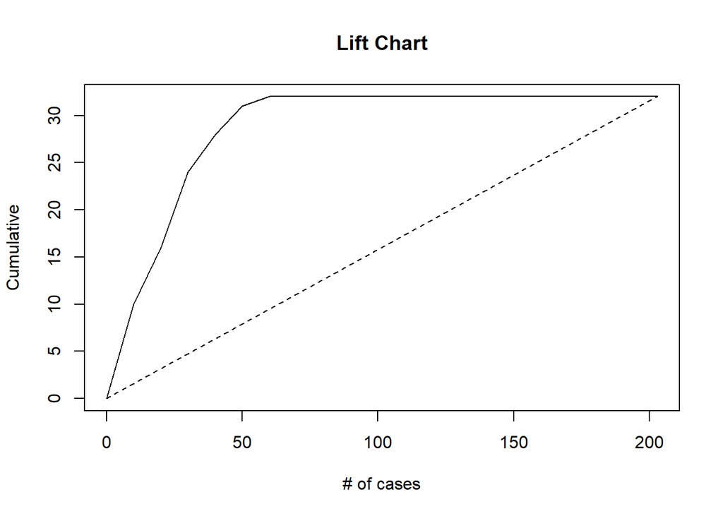

```r
# lift chart
library(gains)
gain <- gains(as.numeric(housing.valid$CAT..MEDV),
exp(housing.da$scores[, 2]) / (exp(housing.da$scores[, 1]) + exp(housing.da$scores[, 2])),
groups = length(housing.valid))

# plot lift chart
plot(c(0, gain$cume.pct.of.total * sum(as.numeric(housing.valid$CAT..MEDV))) ~ c(0, gain$cume.obs),
xlab = "# of cases", ylab = "Cumulative", main = "Lift Chart", type = "l")
lines(c(0, sum(as.numeric(housing.valid$CAT..MEDV))) ~ c(0, nrow(housing.valid)), lty = 2)
```

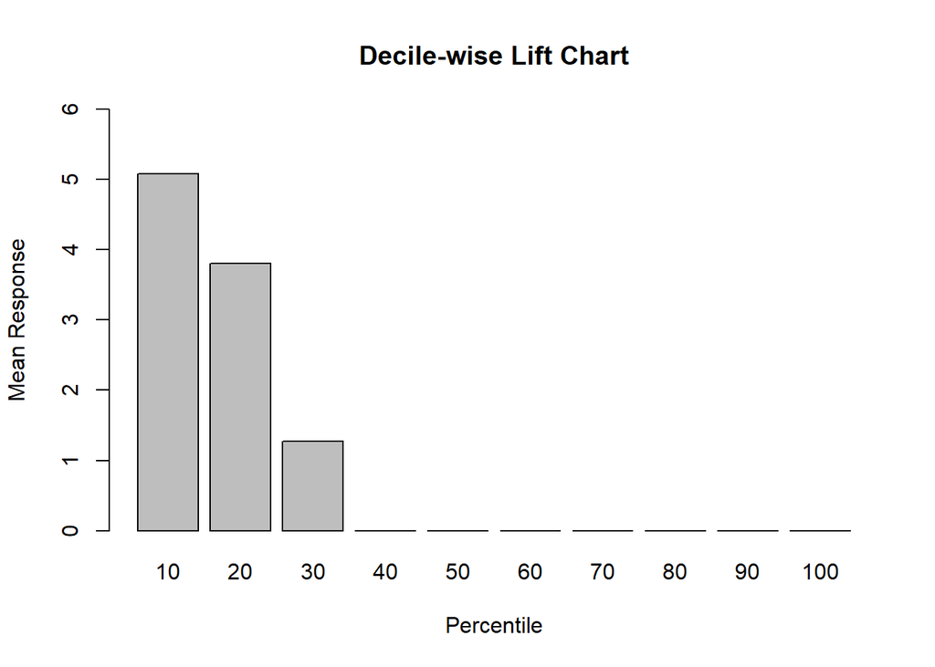

```r
# compute deciles and plot decile-wise lift chart
gain <- gains(as.numeric(housing.valid$CAT..MEDV),
exp(housing.da$scores[, 2]) / (exp(housing.da$scores[, 1]) + exp(housing.da$scores[, 2])))
heights <- gain$mean.resp / mean(as.numeric(housing.valid$CAT..MEDV))
dec.lift <- barplot(heights, names.arg = gain$depth, ylim = c(0, 6),
xlab = "Percentile", ylab = "Mean Response", main = "Decile-wise Lift Chart")
```

What do these tell you about this algorithms ability to classify census tracts as high vs. low value?

Compare these results to the results from the *k*-NN classification. Which algorithm was more accurate overall? Which algorithm did a better job at identifying high-value tracts?

Suppose it is 5 times worse (more costly) to misclassify a “1” as a “0” than to misclassify a “0” as a “1”. We can use the prior argument to account for this much like we did in lecture to account for a difference in actual vs. sample probabilities.

```r
# unequal misclassification costs
housing.da.prior <- linDA(housing.df[, c(1:11, 13:20)], housing.df$CAT..MEDV, prior = c(1, 5) / 6, validation = "learntest",
learn = train.index,
test = valid.index)
```

Note that we converted the cost ratio to probabilities that sum to 1 by dividing by $C_1+C_2$.

```r
housing.da.prior$functions
```

```
##                     0            1
## constant -390.9399403 -397.9662073
## CRIM        0.4539491    0.4618187
## ZN          0.0309337    0.1251176
## INDUS      -0.4619006   -0.5610597
## CHAS        3.9776849    3.7466969
## NOX       231.9040642  227.5444305
## RM         37.6156532   40.8873876
## AGE        -0.1716411   -0.1555026
## DIS         8.4963172    7.4573775
## TAX         0.1706595    0.1696072
## PTRATIO    12.1422076   11.7401058
## LSTAT       1.7615025    1.6558495
## RAD1      107.3133689  103.4168522
## RAD2      124.9374416  124.6265033
## RAD3      118.8995161  121.3377984
## RAD4      102.0815398  101.2157580
## RAD5      110.7487900  110.4494534
## RAD6      111.1931061  107.7581505
## RAD7       92.4936503   92.0529795
## RAD8       99.4615820  100.4799115
```

Note that the classification function constant for “1” increased, while the classification function constant for “0” decreased. The result is akin to lowering the cutoff value in logistic regression in order to capture more successes.

```r
# confusion matrix
confusionMatrix(housing.da.prior$classification,
as.factor(housing.valid$CAT..MEDV),
positive = "1")
```

```
## Confusion Matrix and Statistics
##
##           Reference
## Prediction   0   1
##          0 144   0
##          1  27  32
##
##                Accuracy : 0.867
##                  95% CI : (0.8124, 0.9105)
##     No Information Rate : 0.8424
##     P-Value [Acc > NIR] : 0.1945
##
##                   Kappa : 0.6271
##
##  Mcnemar's Test P-Value : 0.0000005624
##
##             Sensitivity : 1.0000
##             Specificity : 0.8421
##          Pos Pred Value : 0.5424
##          Neg Pred Value : 1.0000
##              Prevalence : 0.1576
##          Detection Rate : 0.1576
##    Detection Prevalence : 0.2906
##       Balanced Accuracy : 0.9211
##
##        'Positive' Class : 1
##
```

You’ll notice that the sensitivity has improved quite a bit (meaning we are now successfully classifying more “1”s), though the overall accuracy has decreased slightly.

# Summary

Things to remember:

- How to use knn() to perform *k*-NN for classification
- How to use knn.reg() to perform *k*-NN for predicting a numerical outcome
- How to find the optimal *k* for both
- How to perform discriminant analysis
- How to account for unequal misclassification costs in discriminant analysis